# Bienvenido al día 1 del workshop de Nuclio Digital School (1/2)

## 14-Enero-2025

[figure not shown]

# Índice

## 1. Intro

1.1 Introducción de Nuclio Digital School  
1.2 Introducción del docente  
1.3 ¿Que es el Data Science?  
1.4 Tipos de recomendadores

## 2. Herramientas utilizadas

2.1 Python: el mejor lenguaje de programación para principiantes  
2.2 Jupyter Notebook: un entorno para codificar  
2.3 Pandas: un "excel vitaminado"  
2.4 Matplotlib: gráficos en Python

## 3. Conclusión

3.1 Conclusión

# 1. Intro

# 1.1 Introducción de Nuclio Digital School

Volver al índice

[figure not shown]

[Nuclio Digital School](https://nuclio.school/) es una escuela de formación en **nuevas tecnologías** con sede en Barcelona, España.

Ofrece masters online y presenciales (en sus campus de Barcelona y Madrid) para aprender las últimas tecnologías del mercado.

Desde sus inicios se ha consolidado como el líder en cursos, masters y bootcamps enfocados a adquirir **las competencias digitales** necesarias para triunfar hoy en día.

Combina **clases intensivas**, **hands-on** y con un **temario actualizado** impartido por los **mejores docentes**, que cuentan con **experiencia real**, para ayudar a sus alumnos a construir **proyectos end-to-end**.

Esta combinación de **docentes/clases prácticas/proyectos e2e** permiten a las personas que acaban el master de Nuclio a **destacar en el mercado laboral y en las entrevistas técnicas**.

Actualmente en [Nuclio Digital School hay un total de 9 Masters](https://nuclio.school/all-programs/) que van desde [Inteligencia Artificial](https://nuclio.school/master-data-science/), [Full Stack Development](https://nuclio.school/master-full-stack-developer/) hasta [Digital Marketing](https://nuclio.school/master-digital-marketing/) y otros.

# 1.2 Introducción del docente

Volver al índice

[Nico](https://www.linkedin.com/in/nico-popescul-a8a1a084/) es un profesional de Data Science y Data Analysis con **9 años de experiencia**.

Su **carrera profesional** ha estado siempre ligada al **sector bancario.**

Ha llevado a cabo proyectos de Analítica Avanzada y/o Machine Learning en algunos de los principales bancos de España y Andorra.

Desde hace Abril-2019 trabaja en **CaixaBank Advanced Business Analytics**, la filial de Analítica Avanzada y ML de CaixaBank.

Desempeña como **Manager de Data Science** y es responsable de puesta en producción y monitorización de modelos **(MLOps)** así como de **creación de arquetipos y nuevas herramientas internas**.

Desde Junio-2020 es profesor en **Nuclio Digital School** e imparte clases de Time Series, Aprendizaje No Supervisado, pandas y scikit-learn en los másters presenciales de Barcelona y Online España.

Licenciado en **Economía por la UPNA**, tiene un postgrado de **Data Science por la Universidad de Barcelona**.

Desde Noviembre de 2023 es **Google Certified Machine Learning Engineer**.

Estuvo en el **top 50 mundial en 2 categorías diferentes** (de un total de 4) de la prestigiosa plataforma Kaggle (> 17 millones de usuarios).

# 1.3 ¿Que es el Data Science?

Volver al índice

El **[Data Science](https://www.ibm.com/think/topics/data-science)** es una disciplina que combina las **matemáticas**, la **programación** y el **conocimiento de negocio** para analizar grandes cantidades de datos y poder **tomar decisiones empresariales**, descubrir **nuevos insights** o bien entender el nuestro alrededor.

[figure not shown]

[Fuente: www.researchgate.net](https://www.researchgate.net/figure/Data-Science-Venn-Diagram_fig1_365946272)

Dentro del mundo de Data Science, existe un subcampo que es el de la Inteligencia Artificial que se encarga de **crear algoritmos y procesos que puedan ayudar a las máquinas a "pensar", tomar decisiones de forma autónoma y resolver problemas complejos**

A su vez, el Machine Learning es otro subconjunto de la IA que entrena algoritmos a partir de grandes cantidades de datos del pasado para detectar patrones y resolver 1 tarea en concreto.

El siguiente árbol es una resumen visual de los diferentes problemas que intenta resolver el Machine Learning:

[figure not shown]

Fuente: Elaboración Propia.

### En nuestro workshop vamos a hablar "Recomendadores" y sus diferentes tipologías.

### Se trata por tanto de un problema de Machine Learning "No Supervisado" de "Asociación".

# 1.4 Tipos de recomendadores

Volver al índice

Ahora que tenemos una idea de lo que es el ML y los problemas que intenta resolver, podemos hacer un overview sobre los diferentes tipos de recomendadores que existen.

No es para nada una lista completa dado que muy a menudo salen nuevas técnicas:

[figure not shown]

[Fuente: www.researchgate.net](https://www.researchgate.net/figure/Types-of-recommender-system_fig2_342967182)

1. **Knowledge Based RS:** es el recomendador más sencillo. A menudo se utiliza cuando tenemos un nuevo cliente y **le preguntamos directamente por las cosas que le gustan**. Por ejemplo cuado nos registramos en una página web y nos preguntan los géneros de películas que nos gustan. Si decimos que nos gustan las películas de terror, el recomendador utilizará esta información para empezar a sugerir películas de terror. Conforme vamos viendo pelis, **empezamos a acumular datos** y entonces podemos empezar a implementar recomendadores más complejos.
2. **Content Based RS:** si tenemos una base de datos con clientes y estos **clientes han usado nuestro servicio**, podemos empezar a hacer una recomendación "content based" en decir, basada en su historial. **Este es el tipo de recomendador que vamos a implementar a lo largo de nuestros workshops.**

### Nuestro gran objetivo a lo largo de estos dos días es seleccionar un cliente al azar de nuestra base de datos y recomendarle aquellos animes que más le podrían gustar.

3. **Collaborative Filtering RS:** es un recomendador más complejo que los dos anteriores porque al contrario que los que vimos antes, empezamos a utilizar algoritmos de ML (en el caso de Model Based) y o bien calculos más complejos (en el caso de Memory Based). Además, son algoritmos que empiezan a requerir mucha cantidad de información para obtener buenos resultados. **Estas dos tipologías de recomendadores son los que implementamos en el Master de Data Science de Nuclio Digital School.**
4. **Hybrid RS**: son ejemplos de recomendadores que combinan las técnicas anteriores u otras (Matrix Factorization, Redes Neuronales etc) para afinar incluso más la recomendación. Por lo general, se consideran técnicas avanzadas y no las vamos a abordar en nuestro workshop.

Antes de empezar a trabajar en nuestro recomendador, veamos un momento que herramientas vamos a utilizar.

# 2. Herramientas utilizadas

# 2.1 Python: el mejor lenguaje de programación para principiantes

Volver al índice

[figure not shown]

[Python](https://www.python.org/) es el lenguaje de programación [más popular del mundo](https://www.tiobe.com/tiobe-index/) y además es considerado el lenguaje más "asequible" y fácil de aprender.

Es un lenguaje que hace mucho hincapié en la simplicidad de la síntaxis así como en que el código sea fácil de leer a la vista.

Python es utilizado para hacer un montón de cosas:

1. Construir páginas web con frameworks como [Flask](https://flask.palletsprojects.com/en/3.0.x/) o [Django](https://www.djangoproject.com/)
2. Entrenar Redes Neuronales con [PyTorch](https://pytorch.org/)
3. Hacer Machine Learning con [sklearn](https://scikit-learn.org/stable/)
4. O bien desarrollar videojuegos con [PyGame](https://www.pygame.org/news)
5. Y un largo etc...

### Empresas como LinkedIn, Instagram, Google o Apple utilizan este lenguaje en sus procesos internos y en muchos de sus productos.

Algunos hasta afirman que [**Artificial General Intelligence (AGI)**](https://es.wikipedia.org/wiki/Inteligencia_artificial_general) será implementado en Python:

[figure not shown]

# 2.2 Jupyter Notebook: un entorno para codificar

Volver al índice

[figure not shown]

Python es un lenguaje de programación pero necesitamos un "entorno de desarrollo". Es decir, un sitio donde podemos escribir, evaluar y ejecutar nuestro código. Para ello vamos a utilizar los [Jupyter Notebook](https://jupyter.org/).

**Jupyter** tiene una interfaz muy sencilla que permite escribir y ejecutar enseguida nuestro código.

**Es una herramienta muy user friendly para empezar a programar o bien hacer análisis de datos.**

Los notebooks son muy utilizados por los equipos de Data Science porque permiten generar documentos que son fáciles de compartir y muy visuales. En Jupyter podemos insertar imágenes, texto formateado, latex además de código.

**Ahora mismo, estáis viendo todo el contenido dentro de un Jupyter Notebook.**

```python
print("Estamos usando Python dentro de un Jupyter Notebook")
```

```
Estamos usando Python dentro de un Jupyter Notebook
```

[Kaggle](https://www.kaggle.com/) o bien [Colab](https://colab.research.google.com/) son dos plataformas (propiedad de Google) gratuitas para aprender Python y Data Science que utilizan la tecnología de Jupyter Notebooks.

# 2.3 Pandas: un "excel vitaminado"

Volver al índice

[figure not shown]

[Pandas](https://pandas.pydata.org/) es una herramienta muy flexible para hacer **análisis de datos tabulares.**

Es uno de los software más utilizados dentro del mundo de Python con un total de [291.340.824](https://pypistats.org/packages/pandas) descargas en Diciembre-2024.

Podemos pensar en pandas como una especie de "Excel Vitaminado" que nos permite hacer sumas, diferentes agrupaciones, tablas dinámicas y análisis directamente desde Python.

Los objetos de pandas los llamamos **"DataFrames"** y son lo que nos permite manipular con facilidad nuestros datos.

Veamos un ejemplo muy sencillo:

```python
#      MINI-DEMO
# --------------------

import pandas as pd
```

```python
df = pd.read_parquet("./input/cf_anime.parquet.gzip")
```

```python
df["type"].unique()
```

```
array(['Movie', 'TV', 'OVA', 'Special', 'Music', 'ONA', None],
      dtype=object)
```

```python
pt = df.pivot_table(
    index = "type",
    values = "rating",
    aggfunc = len
).sort_values(by = "rating", ascending = False)
```

```python
pt
```

| type | rating |
| --- | --- |
| TV | 3787 |
| OVA | 3311 |
| Movie | 2348 |
| Special | 1676 |
| ONA | 659 |
| Music | 488 |

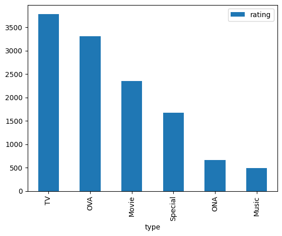

```python
pt.plot(kind = "bar")
```

# 2.4 Matplotlib: gráficos en Python

Volver al índice

Por último en nuestro workshop vamos a trabajar con [matplotlib](https://matplotlib.org/).

**Matplotlib** es una de las librerías más antiguas de Python y una de las más utilizadas con [64.156.870](https://pypistats.org/packages/matplotlib) de descargas en el mes de Diciembre-2024.

Esta librería se usa para hacer [gráficos muy avanzadas](https://numpy.org/case-studies/blackhole-image/) y de una calidad excepcional porque da total acceso a los elementos de un plot.

En el [siguiente enlace](https://www.kaggle.com/code/nicopyds/learn-matpotlib-doing-50-plots) tenéis una pequeña colección de diferentes gráficos que se pueden realizar con Matplotlib.

[figure not shown]

# 3. Conclusión

# 3.1 Conclusión

Volver al índice

El ecosistema de Python y las librerías que se han generado alrededor son herramientas muy versátiles que se utilizan a diario por millones de programadores y data scientists de todo el mundo.

En empresas tan punteras como [Google: Python es uno de los 5 "lenguajes oficiales" para subir a producción.](https://arxiv.org/pdf/1702.01715)

A su vez, el ecosistema Python es utilizado para hacer algunos de los grandes descubrimientos del siglo XXI.

[figure not shown]

## Nunca ha habido un mejor momento de aprender a programar en Python.

Nos vemos en el siguiente PANDAS.ipynb